# Evaluacija e-kolegija temeljem vanjskih podataka

Projektni zadatak - Analitika učenja

Petar Prenc

2026-06-20

# 1 Uvod i definicija izvora podataka

## 1.1 Opis skupa podataka

Ovaj projektni zadatak koristi skup podataka **Student Academic Performance (SAP)** koji je javno dostupan na repozitoriju UCI Machine Learning Repository (https://archive.ics.uci.edu/dataset/467/student+academics+performance).

Skup podataka prikupljen je na Engineering Collegeu u Assamu (Indija) i sadrži **131 studentski zapis** s **22 atributa** koji opisuju demografske, socioekonomske i akademske karakteristike studenata. Podaci nisu sintetički - prikupljeni su upitnikom koji su ispunjavali stvarni studenti, te su stoga prikladni za evaluaciju e-kolegija iz vanjske (izvan-LMS) perspektive.

## 1.2 Atributi skupa podataka

| Kratica | Opis | Vrijednosti |
| --- | --- | --- |
| `ge` | Spol | M, F |
| `cst` | Kastinska kategorija | G, ST, SC, OBC, MOBC |
| `tnp` | Ocjena u prethodnom semestru | Best, Vg, Good, Pass, Fail |
| `twp` | Ocjena u tekućem semestru | Best, Vg, Good, Pass, Fail |
| `iap` | Ocjena iz internih provjera | Best, Vg, Good, Pass, Fail |
| `esp` | Očekivana završna ocjena | Best, Vg, Good, Pass, Fail |
| `arr` | Ponavljanje godine | Y, N |
| `ms` | Bračni status | Married, Unmarried |
| `ls` | Lokacija stanovanja | T (Town), V (Village) |
| `as` | Vrsta smještaja | Free, Paid |
| `fmi` | Prihod obitelji | Vh, High, Am, Medium, Low |
| `fs` | Veličina obitelji | Large, Average, Small |
| `fq` | Obrazovanje oca | Il, Um, 10, 12, Degree, Pg |
| `mq` | Obrazovanje majke | Il, Um, 10, 12, Degree, Pg |
| `fo` | Zanimanje oca | Service, Business, Retired, Farmer, Others |
| `mo` | Zanimanje majke | Service, Business, Retired, Housewife, Others |
| `nf` | Broj prijatelja | Large, Average, Small |
| `sh` | Stambeni uvjeti | Good, Average, Poor |
| `ss` | Vrsta srednje škole | Govt, Private |
| `me` | Jezik nastave | Eng, Asm, Hin, Ben |
| `tt` | Putovanje do škole | Large, Average, Small |
| `atd` | Pohađanje nastave | Good, Average, Poor |

## 1.3 Svrha uporabe u evaluaciji e-kolegija

Ovaj skup podataka predstavlja **vanjske podatke** koji nisu direktno zabilježeni unutar sustava e-učenja (LMS), a omogućuju evaluaciju e-kolegija iz sljedećih perspektiva:

1. **Identifikacija rizičnih profila studenata** - kombinacijom socioekonomskih i prethodnih akademskih pokazatelja moguće je prepoznati studente koji će imati poteškoće s online oblicima učenja još prije nego što oni nastupe.
2. **Razumijevanje kontekstualnih barijera** - podaci o lokaciji stanovanja, prijevozu, prihodima obitelji i tipu smještaja otkrivaju vanjske čimbenike koji ometaju redovito pohađanje e-nastave (npr. nedostatak interneta ili tihog prostora za učenje).
3. **Praćenje konzistentnosti akademskog napretka** - usporedba ocjene iz prethodnog semestra (`tnp`) s tekućim i očekivanim rezultatima (`twp`, `esp`) pruža uvid u to koliko je e-kolegij pridonio ili oduzeo od akademskog napretka studenata.
4. **Diferencirana podrška** - podaci o pohađanju nastave uživo (`atd`) u kombinaciji s prethodnim uspjehom omogućuju dizajn ciljanih intervencija unutar e-kolegija za specifične podskupine studenata.

## 1.4 Vrste analiza koje podatci omogućuju

Kategorijska i ordinalna priroda varijabli (ocjene, pohađanje, prihod) te njihova mješovita skala čine ovaj skup podataka prikladnim za sljedeće analitičke pristupe:

- **Deskriptivna statistika** — frekvencijske distribucije, kontingencijske tablice i mjere centralne tendencije na numeričkim kodiranjima ordinalnih varijabli; prikladno za profiliranje studentske populacije i praćenje KPI-ja.
- **Dijagnostička analiza** — identifikacija obrazaca između podskupina (pohađanje prema prihodima, lokaciji, spolu); omogućuje određivanje koji kontekstualni čimbenici najviše koreliraju s lošim akademskim ishodima.
- **Korelacijska i regresijska analiza** — kvantifikacija veze između socioekonomskih varijabli i akademskih ishoda; regresijski koeficijenti daju interpretabilnu mjeru relativnog doprinosa svake varijable što je izravno prenosivo u preporuke za dizajn e-kolegija.
- **Klaster analiza** — nesupervizirano grupiranje studenata u homogene profile prema kombinaciji akademskih i socioekonomskih karakteristika; rezultati se koriste za oblikovanje diferenciranih putanja učenja.
- **Prediktivna klasifikacija** — treniranje modela (npr. Random Forest) koji na temelju profila studenta prikupljenog na početku kolegija predviđaju pohađanje ili akademski ishod, čime se omogućuje proaktivna identifikacija studenata u riziku.

# 2 Učitavanje i priprema podataka

```r
# Instalacija potrebnih paketa (ako nisu instalirani)
required_packages <- c(
  "tidyverse", "knitr", "kableExtra", "foreign",
  "ggplot2", "ggmosaic", "scales", "RColorBrewer",
  "cluster", "factoextra", "randomForest",
  "caret", "corrplot", "vcd", "gridExtra", "broom"
)

install_if_missing <- function(pkg) {
  if (!requireNamespace(pkg, quietly = TRUE))
    install.packages(pkg, repos = "https://cloud.r-project.org")
}
invisible(lapply(required_packages, install_if_missing))

# Učitavanje paketa
library(tidyverse)
library(knitr)
library(kableExtra)
library(foreign)
library(ggplot2)
library(scales)
library(RColorBrewer)
library(cluster)
library(factoextra)
library(randomForest)
library(caret)
library(vcd)
```

```r
# Učitavanje ARFF datoteke
sap_raw <- read.arff("Sapfile1.arff")

# Pregled strukture
glimpse(sap_raw)
```

```
## Rows: 131
## Columns: 22
## $ ge  <fct> F, M, F, M, M, M, F, F, F, F, M, F, M, M, F, F, F, M, M, M, F, F, …
## $ cst <fct> G, OBC, OBC, MOBC, G, OBC, OBC, OBC, MOBC, OBC, ST, OBC, OBC, OBC,…
## $ tnp <fct> Good, Vg, Good, Pass, Good, Vg, Good, Good, Vg, Vg, Vg, Vg, Good, …
## $ twp <fct> Good, Vg, Good, Good, Good, Good, Vg, Good, Good, Vg, Vg, Vg, Good…
## $ iap <fct> Vg, Vg, Vg, Vg, Vg, Vg, Good, Good, Good, Good, Good, Good, Good, …
## $ esp <fct> Good, Vg, Good, Good, Vg, Vg, Good, Good, Vg, Vg, Vg, Vg, Good, Vg…
## $ arr <fct> Y, N, N, N, N, N, N, N, Y, Y, N, N, Y, N, N, Y, N, Y, Y, Y, N, Y, …
## $ ms  <fct> Unmarried, Unmarried, Unmarried, Unmarried, Unmarried, Unmarried, …
## $ ls  <fct> V, V, V, V, V, V, V, V, V, V, V, V, V, V, V, V, V, V, V, V, V, V, …
## $ as  <fct> Paid, Paid, Paid, Paid, Paid, Paid, Paid, Paid, Paid, Paid, Paid, …
## $ fmi <fct> Medium, Low, Am, Medium, Am, Medium, High, Medium, Low, Low, Vh, M…
## $ fs  <fct> Average, Average, Average, Small, Average, Average, Average, Small…
## $ fq  <fct> Um, Um, 12, 12, 10, 10, 12, Il, 12, Degree, Pg, Degree, Degree, Il…
## $ mq  <fct> 10, Il, 10, Um, 12, Um, Degree, Um, 10, Degree, Pg, 12, 10, Il, 10…
## $ fo  <fct> Farmer, Service, Service, Business, Service, Farmer, Service, Farm…
## $ mo  <fct> Housewife, Service, Housewife, Business, Housewife, Housewife, Ser…
## $ nf  <fct> Large, Small, Average, Large, Large, Small, Average, Small, Small,…
## $ sh  <fct> Poor, Poor, Average, Poor, Poor, Poor, Poor, Poor, Good, Average, …
## $ ss  <fct> Govt, Govt, Govt, Govt, Private, Private, Govt, Private, Govt, Gov…
## $ me  <fct> Asm, Asm, Asm, Asm, Asm, Eng, Asm, Asm, Asm, Asm, Eng, Eng, Eng, A…
## $ tt  <fct> Small, Average, Large, Average, Small, Average, Small, Average, Av…
## $ atd <fct> Good, Average, Good, Average, Good, Average, Good, Good, Good, Goo…
```

```r
# Preimenovanje stupaca za jasniju čitljivost
sap <- sap_raw %>%
  rename(
    spol            = ge,
    kasta           = cst,
    ocjena_prosli   = tnp,
    ocjena_tekuci   = twp,
    interna_provjera = iap,
    ocjena_ocekivana = esp,
    ponavljanje     = arr,
    bracni_status   = ms,
    lokacija        = ls,
    smjestaj        = as,
    prihod_obitelji = fmi,
    velicina_obitelji = fs,
    obrazovanje_oca = fq,
    obrazovanje_majke = mq,
    zanimanje_oca   = fo,
    zanimanje_majke = mo,
    broj_prijatelja = nf,
    uvjeti_stanovanja = sh,
    vrsta_skole     = ss,
    jezik_nastave   = me,
    putovanje       = tt,
    pohadjanje      = atd
  )

# Definiranje redoslijeda razina za ordinalnu varijablu ocjene
razine_ocjena <- c("Fail", "Pass", "Good", "Vg", "Best")

sap <- sap %>%
  mutate(
    ocjena_prosli    = factor(ocjena_prosli,    levels = razine_ocjena, ordered = TRUE),
    ocjena_tekuci    = factor(ocjena_tekuci,    levels = razine_ocjena, ordered = TRUE),
    interna_provjera = factor(interna_provjera, levels = razine_ocjena, ordered = TRUE),
    ocjena_ocekivana = factor(ocjena_ocekivana, levels = razine_ocjena, ordered = TRUE),
    # Numeričke vrijednosti za ordinalne ocjene (za modeliranje)
    ocjena_prosli_num    = as.numeric(ocjena_prosli),
    ocjena_tekuci_num    = as.numeric(ocjena_tekuci),
    interna_provjera_num = as.numeric(interna_provjera),
    ocjena_ocekivana_num = as.numeric(ocjena_ocekivana)
  )

# Pregled prvih redova
head(sap, 5) %>%
  select(spol, kasta, ocjena_prosli, ocjena_tekuci,
         ocjena_ocekivana, pohadjanje, prihod_obitelji) %>%
  kable(caption = "Prvih 5 zapisa skupa podataka (odabrani stupci)") %>%
  kable_styling(bootstrap_options = c("striped", "hover", "condensed"), full_width = FALSE)
```

Prvih 5 zapisa skupa podataka (odabrani stupci)

| spol | kasta | ocjena_prosli | ocjena_tekuci | ocjena_ocekivana | pohadjanje | prihod_obitelji |
| --- | --- | --- | --- | --- | --- | --- |
| F | G | Good | Good | Good | Good | Medium |
| M | OBC | Vg | Vg | Vg | Average | Low |
| F | OBC | Good | Good | Good | Good | Am |
| M | MOBC | Pass | Good | Good | Average | Medium |
| M | G | Good | Good | Vg | Good | Am |

```r
cat("Dimenzije skupa podataka:", nrow(sap), "redaka x", ncol(sap), "stupaca\n")
```

```
## Dimenzije skupa podataka: 131 redaka x 26 stupaca
```

```r
cat("Nedostajuće vrijednosti:", sum(is.na(sap)), "\n")
```

```
## Nedostajuće vrijednosti: 0
```

# 3 Definiranje ključnih pokazatelja uspješnosti (KPI-ji)

Ključni pokazatelji uspješnosti (KPI-ji) operacionaliziraju ciljeve evaluacije e-kolegija u mjerljive, praćljive i usporedive veličine. Bez jasno definiranih KPI-ja analiza ostaje opisna — KPI-ji daju normativni okvir koji omogućuje zaključivanje o tome je li e-kolegij uspješan i u kojim dimenzijama treba intervenciju.

U ovom projektu definirano je pet KPI-ja koji se izravno izračunavaju iz dostupnih vanjskih (izvan-LMS) podataka i pokrivaju četiri evaluacijske dimenzije: **angažiranost**, **akademski napredak**, **prolaznost** i **valjanost vrednovanja**.

## 3.1 Pregled i definicije KPI-ja

| KPI | Naziv | Definicija | Mjeri | Ciljna vrijednost |
| --- | --- | --- | --- | --- |
| **KPI-1** | Stopa aktivnog pohađanja (SAP) | Udio studenata s pohađanjem *Good* | Angažiranost | > 60 % |
| **KPI-2** | Indeks akademskog napretka (IAP) | Prosj. promjena ocjene tekući − prošli sem. | Napredak | > 0 (pozitivan) |
| **KPI-3** | Stopa očekivane prolaznosti (SOP) | Udio studenata s očekivanom ocjenom ≥ *Good* | Prolaznost | > 70 % |
| **KPI-4** | Stopa rizičnih studenata (SRS) | Udio studenata s pohađanjem *Poor* i ocjenom ≤ *Pass* | Rizik | < 15 % |
| **KPI-5** | Konzistentnost formativnog vrednovanja (KFV) | Spearmanova korelacija: interna provjera ↔︎ završna ocjena | Vrednovanje | > 0,60 |

**KPI-1 (SAP) — cilj > 60 %:** Pohađanje nastave primarni je indikator angažiranosti. Credé et al. (2010) u meta-analizi na uzorku od 69 studija utvrdili su da pohađanje ispod 60 % snažno korelira s povećanim rizikom od akademskog neuspjeha (r = −0,39). Prag od 60 % odabran je kao minimalni standard angažiranosti koji razdvaja “aktivnu” od “pasivne” studentske populacije.

**KPI-2 (IAP) — cilj > 0:** Neutralna referentna vrijednost — svaki pozitivni pomak između semestara znači mjerljivi akademski napredak koji se može djelomično pripisati e-kolegiju kao kontekstu učenja. Negativan indeks signalizira regresiju i zahtijeva intervenciju.

**KPI-3 (SOP) — cilj > 70 %:** Prag od 70 % prolaznosti pragmatičan je standard koji se široko koristi u visokoobrazovnoj analitici (vidi npr. Tinto, 1987; Bean & Metzner, 1985) i konzistentan je s praksom ECTS sustava u kojemu se ocjene A–C (ekvivalent *Good* i više) dodjeljuju otprilike gornjim 70 % uspješne populacije. ESG (ENQA, 2015) ne propisuje konkretne numeričke pragove prolaznosti, ali naglašava kontinuirano praćenje studentskog napretka kao kriterij kvalitete. Vrijednosti ispod 70 % upućuju na previsok kognitivni teret ili nedovoljnu podršku studentima.

**KPI-4 (SRS) — cilj < 15 %:** Pragmatični prag temeljen na literaturi o “at-risk” studentima — Arnold & Pistilli (2012) u sustavu Course Signals utvrdili su da intervencija postaje neophodna kad udio rizičnih studenata prelazi 10–15 %. Granica od 15 % balansira između preosjetljivog alarma i kasne reakcije.

**KPI-5 (KFV) — cilj > 0,60:** Psihometrijski standard prema Campbell & Fiske (1959): konvergentna valjanost smatra se prihvatljivom kad korelacija između dvaju mjerenja istog konstrukta prelazi 0,50–0,60. Cohen (1988) klasificira ρ = 0,50 kao “velik” efekt u kontekstu statističke snage, što potvrđuje da je prag od 0,60 konzervativan minimum koji osigurava da formativne provjere smisleno predviđaju završni ishod.

## 3.2 Izračun i ocjena KPI-ja

```r
library(gridExtra)

# KPI-1: Stopa aktivnog pohađanja
kpi_sap <- round(mean(sap$pohadjanje == "Good") * 100, 1)

# KPI-2: Indeks akademskog napretka
kpi_iap <- round(mean(sap$ocjena_tekuci_num - sap$ocjena_prosli_num), 3)

# KPI-3: Stopa ocekivane prolaznosti (ocjena >= Good, tj. >= razina 3)
kpi_sop <- round(mean(sap$ocjena_ocekivana_num >= 3) * 100, 1)

# KPI-4: Stopa rizicnih studenata (Poor pohadjanje + ocjena <= Pass)
kpi_srs <- round(mean(sap$pohadjanje == "Poor" & sap$ocjena_ocekivana_num <= 2) * 100, 1)

# KPI-5: Konzistentnost formativnog vrednovanja
kpi_kfv <- round(cor(sap$interna_provjera_num, sap$ocjena_ocekivana_num,
                     method = "spearman"), 3)

# Sumarni pregled KPI-ja
tibble(
  KPI     = c("KPI-1: SAP", "KPI-2: IAP", "KPI-3: SOP", "KPI-4: SRS", "KPI-5: KFV"),
  `Izmjerena vrijednost` = c(
    paste0(hr(kpi_sap), " %"),
    hr(kpi_iap),
    paste0(hr(kpi_sop), " %"),
    paste0(hr(kpi_srs), " %"),
    hr(kpi_kfv)
  ),
  `Ciljna vrijednost` = c("> 60 %", "> 0", "> 70 %", "< 15 %", "> 0,60"),
  `Status` = c(
    ifelse(kpi_sap > 60, "Zadovoljava", "Ne zadovoljava"),
    ifelse(kpi_iap > 0,  "Zadovoljava", "Ne zadovoljava"),
    ifelse(kpi_sop > 70, "Zadovoljava", "Ne zadovoljava"),
    ifelse(kpi_srs < 15, "Zadovoljava", "Ne zadovoljava"),
    ifelse(kpi_kfv > 0.6,"Zadovoljava", "Ne zadovoljava")
  )
) %>%
  kable(caption = "Ključni pokazatelji uspješnosti e-kolegija — izmjerene vrijednosti") %>%
  kable_styling(bootstrap_options = c("striped", "hover", "condensed"),
                full_width = FALSE) %>%
  column_spec(4, bold = TRUE,
              color = ifelse(
                c(kpi_sap > 60, kpi_iap > 0, kpi_sop > 70,
                  kpi_srs < 15, kpi_kfv > 0.6),
                "#388E3C", "#D32F2F"))
```

Ključni pokazatelji uspješnosti e-kolegija — izmjerene vrijednosti

| KPI | Izmjerena vrijednost | Ciljna vrijednost | Status |
| --- | --- | --- | --- |
| KPI-1: SAP | 42,7 % | > 60 % | Ne zadovoljava |
| KPI-2: IAP | 0,046 | > 0 | Zadovoljava |
| KPI-3: SOP | 79,4 % | > 70 % | Zadovoljava |
| KPI-4: SRS | 9,9 % | < 15 % | Zadovoljava |
| KPI-5: KFV | 0,517 | > 0,60 | Ne zadovoljava |

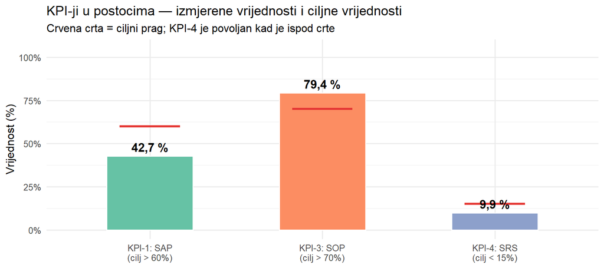

```r
# Graficki prikaz postotnih KPI-ja s ciljnim vrijednostima
kpi_postoci <- tibble(
  KPI        = c("KPI-1: SAP\n(cilj > 60%)", "KPI-3: SOP\n(cilj > 70%)",
                 "KPI-4: SRS\n(cilj < 15%)"),
  Vrijednost = c(kpi_sap, kpi_sop, kpi_srs),
  Cilj       = c(60, 70, 15)
)

ggplot(kpi_postoci, aes(x = KPI, y = Vrijednost, fill = KPI)) +
  geom_col(width = 0.5, color = "white") +
  geom_errorbar(aes(ymin = Cilj, ymax = Cilj),
                color = "#E53935", linewidth = 1.2, width = 0.35) +
  geom_text(aes(label = paste0(hr(Vrijednost), " %")),
            vjust = -0.5, size = 4.5, fontface = "bold") +
  scale_fill_brewer(palette = "Set2") +
  scale_y_continuous(limits = c(0, 105), labels = function(x) paste0(x, "%")) +
  labs(
    title    = "KPI-ji u postocima — izmjerene vrijednosti i ciljne vrijednosti",
    subtitle = "Crvena crta = ciljni prag; KPI-4 je povoljan kad je ispod crte",
    x = NULL, y = "Vrijednost (%)"
  ) +
  theme_minimal(base_size = 12) +
  theme(legend.position = "none")
```

## 3.3 Tumačenje KPI-ja

- **KPI-1 (SAP = 42,7 %):** Stopa pohađanja ne dostiže ciljnih 60 %, što ukazuje na potrebu za intervencijama koje potiču redovitu participaciju u e-nastavi.
- **KPI-2 (IAP = 0,046):** Pozitivan indeks pokazuje da studenti u prosjeku bilježe akademski napredak između semestara. Napomena: budući da se radi o opservacijskim podacima, napredak nije moguće kauzalno pripisati e-kolegiju — na njega mogu utjecati sazrijevanje, druge kolegije ili vanjski faktori.
- **KPI-3 (SOP = 79,4 %):** Više od 70 % studenata očekuje završnu ocjenu Good ili višu — e-kolegij postiže zadovoljavajuću razinu ishoda učenja.
- **KPI-4 (SRS = 9,9 %):** Udio rizičnih studenata je ispod kritičnog praga od 15 %, no i ta skupina zahtijeva ciljanu podršku unutar e-kolegija.
- **KPI-5 (KFV = 0,517):** Korelacija ispod 0,60 upozorava na neskladnost između formativnih provjera i završnih ishoda — potrebno je revidirati instrumente vrednovanja.

# 4 Deskriptivna statistika i dijagnostička analiza

Sljedeće analize dublje istražuju dimenzije koje stoje iza definiranih KPI-ja: distribuciju ocjena (KPI-2, KPI-3), pohađanje nastave (KPI-1, KPI-4) te međuodnose ocjenskih varijabli (KPI-5).

## 4.1 Raspodjela akademskih ocjena

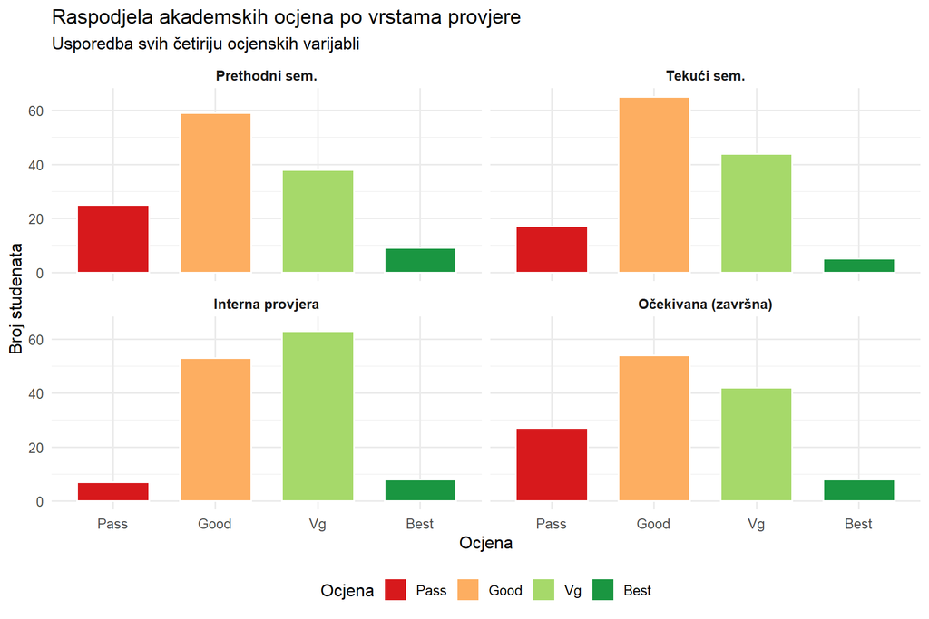

```r
# Dugi format za usporedbu svih ocjenskih varijabli
ocjene_dugi <- sap %>%
  select(ocjena_prosli, ocjena_tekuci, interna_provjera, ocjena_ocekivana) %>%
  pivot_longer(everything(), names_to = "vrsta_ocjene", values_to = "ocjena") %>%
  mutate(
    vrsta_ocjene = recode(vrsta_ocjene,
      "ocjena_prosli"    = "Prethodni sem.",
      "ocjena_tekuci"    = "Tekući sem.",
      "interna_provjera" = "Interna provjera",
      "ocjena_ocekivana" = "Očekivana (završna)"
    ),
    vrsta_ocjene = factor(vrsta_ocjene,
      levels = c("Prethodni sem.", "Tekući sem.",
                 "Interna provjera", "Očekivana (završna)"))
  )

ggplot(ocjene_dugi, aes(x = ocjena, fill = ocjena)) +
  geom_bar(color = "white", width = 0.7) +
  facet_wrap(~vrsta_ocjene, ncol = 2) +
  scale_fill_brewer(palette = "RdYlGn", direction = 1) +
  labs(
    title    = "Raspodjela akademskih ocjena po vrstama provjere",
    subtitle = "Usporedba svih četiriju ocjenskih varijabli",
    x = "Ocjena", y = "Broj studenata", fill = "Ocjena"
  ) +
  theme_minimal(base_size = 12) +
  theme(legend.position = "bottom",
        strip.text = element_text(face = "bold"))
```

```r
# Frekvencijske tablice za svaku ocjensku varijablu
prikazi_tablicu <- function(var, naziv) {
  tbl <- table(var)
  pct <- round(prop.table(tbl) * 100, 1)
  data.frame(
    Ocjena    = names(tbl),
    Frekvencija = as.integer(tbl),
    Postotak  = paste0(hr(pct), " %")
  ) %>%
    kable(caption = naziv) %>%
    kable_styling(bootstrap_options = c("striped","condensed"), full_width = FALSE)
}

prikazi_tablicu(sap$ocjena_prosli,    "Ocjene iz prethodnog semestra")
```

Ocjene iz prethodnog semestra

| Ocjena | Frekvencija | Postotak |
| --- | --- | --- |
| Fail | 0 | 0,0 % |
| Pass | 25 | 19,1 % |
| Good | 59 | 45,0 % |
| Vg | 38 | 29,0 % |
| Best | 9 | 6,9 % |

```r
prikazi_tablicu(sap$ocjena_tekuci,    "Ocjene iz tekućeg semestra")
```

Ocjene iz tekućeg semestra

| Ocjena | Frekvencija | Postotak |
| --- | --- | --- |
| Fail | 0 | 0,0 % |
| Pass | 17 | 13,0 % |
| Good | 65 | 49,6 % |
| Vg | 44 | 33,6 % |
| Best | 5 | 3,8 % |

```r
prikazi_tablicu(sap$ocjena_ocekivana, "Očekivane završne ocjene")
```

Očekivane završne ocjene

| Ocjena | Frekvencija | Postotak |
| --- | --- | --- |
| Fail | 0 | 0,0 % |
| Pass | 27 | 20,6 % |
| Good | 54 | 41,2 % |
| Vg | 42 | 32,1 % |
| Best | 8 | 6,1 % |

**Tumačenje:** Dominantne kategorije u svim mjerenjima su *Good* i *Vg* (Very Good), što upućuje na pretežno srednje do dobro akademski uspješnu populaciju. Vrijedni pažnje su podaci da relativno mali broj studenata dostiže kategoriju *Best*, dok kategorija *Fail* u skupu podataka **uopće ne postoji** (nula zapisa u sve četiri ocjenske varijable; iako je razina definirana u ordinalnoj skali radi potpunosti, ona je prazna). To snažno upućuje na selekcijsku pristranost uzorka (studenti koji apsolviraju nastavu češće sudjeluju u anketama) i istodobno znači da efektivna ocjenska skala u ovim podacima ima samo četiri razine (*Pass*–*Best*), što treba imati na umu pri tumačenju numeričkih kodiranja.

## 4.2 Demografski profil studenata

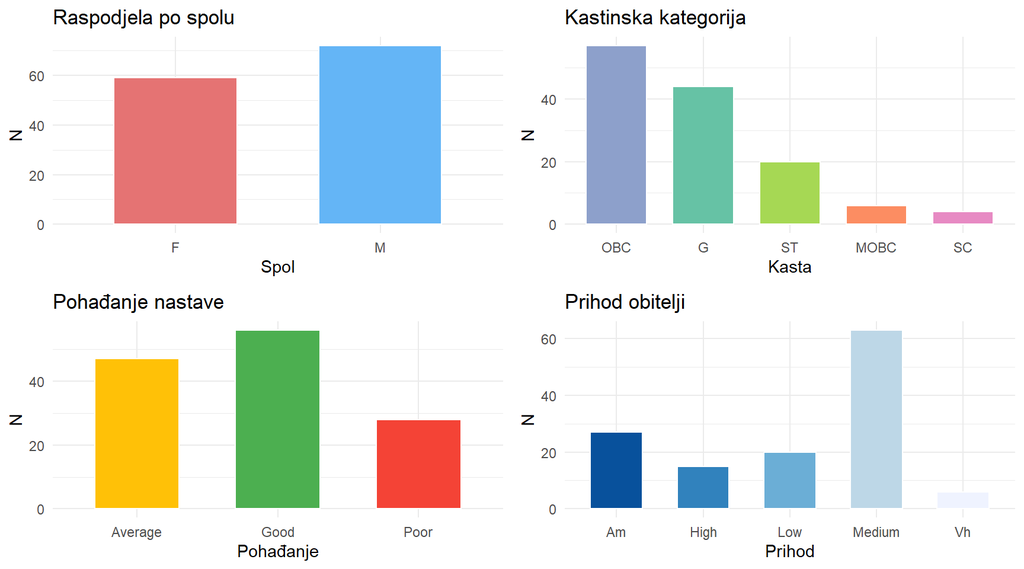

```r
p1 <- ggplot(sap, aes(x = spol, fill = spol)) +
  geom_bar(width = 0.6, color = "white") +
  scale_fill_manual(values = c("F" = "#E57373", "M" = "#64B5F6")) +
  labs(title = "Raspodjela po spolu", x = "Spol", y = "N") +
  theme_minimal() + theme(legend.position = "none")

p2 <- ggplot(sap, aes(x = fct_infreq(kasta), fill = kasta)) +
  geom_bar(width = 0.7, color = "white") +
  scale_fill_brewer(palette = "Set2") +
  labs(title = "Kastinska kategorija", x = "Kasta", y = "N") +
  theme_minimal() + theme(legend.position = "none")

p3 <- ggplot(sap, aes(x = pohadjanje, fill = pohadjanje)) +
  geom_bar(width = 0.6, color = "white") +
  scale_fill_manual(values = c("Good" = "#4CAF50", "Average" = "#FFC107", "Poor" = "#F44336")) +
  labs(title = "Pohađanje nastave", x = "Pohađanje", y = "N") +
  theme_minimal() + theme(legend.position = "none")

p4 <- ggplot(sap, aes(x = prihod_obitelji, fill = prihod_obitelji)) +
  geom_bar(width = 0.6, color = "white") +
  scale_fill_brewer(palette = "Blues", direction = -1) +
  labs(title = "Prihod obitelji", x = "Prihod", y = "N") +
  theme_minimal() + theme(legend.position = "none")

gridExtra::grid.arrange(p1, p2, p3, p4, ncol = 2)
```

```r
# Odnos pohađanja nastave i ocjena po spolu
sap %>%
  count(spol, pohadjanje) %>%
  group_by(spol) %>%
  mutate(pct = round(n / sum(n) * 100, 1)) %>%
  pivot_wider(names_from = pohadjanje, values_from = c(n, pct), values_fill = 0) %>%
  kable(caption = "Pohađanje nastave prema spolu (broj i postotak)",
        format.args = list(decimal.mark = ",")) %>%
  kable_styling(bootstrap_options = c("striped","condensed"), full_width = FALSE)
```

Pohađanje nastave prema spolu (broj i postotak)

| spol | n_Average | n_Good | n_Poor | pct_Average | pct_Good | pct_Poor |
| --- | --- | --- | --- | --- | --- | --- |
| F | 19 | 33 | 7 | 32,2 | 55,9 | 11,9 |
| M | 28 | 23 | 21 | 38,9 | 31,9 | 29,2 |

## 4.3 Dijagnostička analiza: Pohađanje nastave i akademski uspjeh

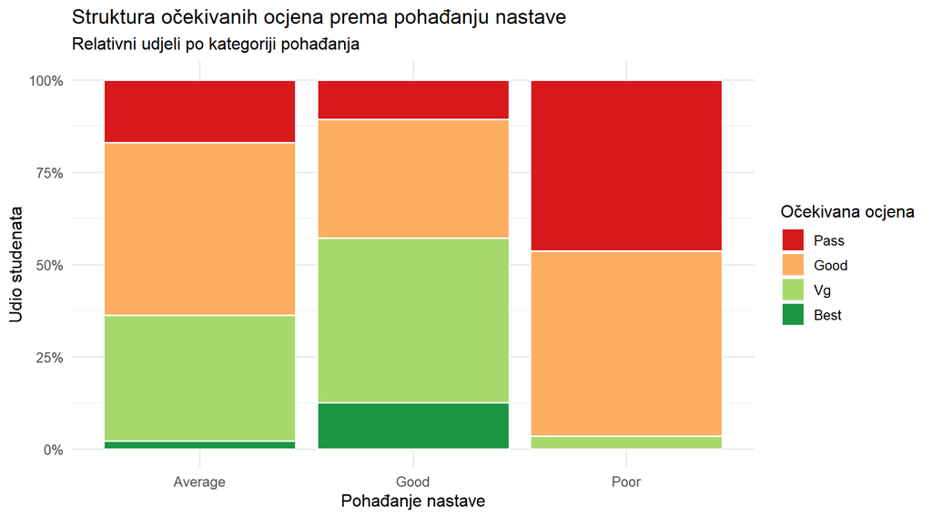

```r
# Mozaik plot - pohađanje i očekivana ocjena
ggplot(sap, aes(x = pohadjanje, fill = ocjena_ocekivana)) +
  geom_bar(position = "fill", color = "white") +
  scale_fill_brewer(palette = "RdYlGn") +
  scale_y_continuous(labels = percent_format()) +
  labs(
    title    = "Struktura očekivanih ocjena prema pohađanju nastave",
    subtitle = "Relativni udjeli po kategoriji pohađanja",
    x = "Pohađanje nastave", y = "Udio studenata",
    fill = "Očekivana ocjena"
  ) +
  theme_minimal(base_size = 12)
```

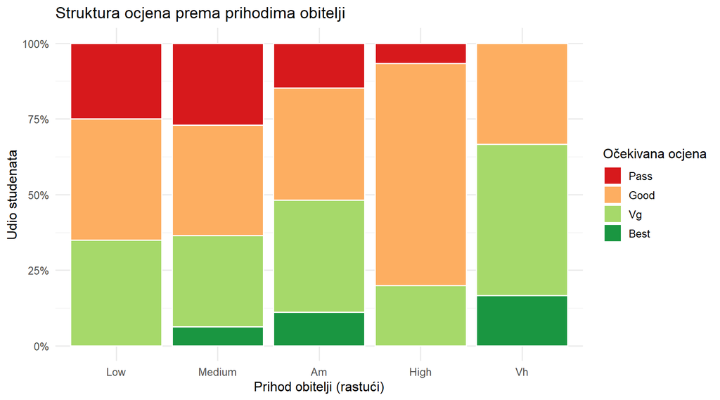

```r
# Prihod obitelji i ocjena
prihod_red <- c("Low", "Medium", "Am", "High", "Vh")
sap_plot <- sap %>%
  mutate(prihod_obitelji = factor(prihod_obitelji, levels = prihod_red))

ggplot(sap_plot, aes(x = prihod_obitelji, fill = ocjena_ocekivana)) +
  geom_bar(position = "fill", color = "white") +
  scale_fill_brewer(palette = "RdYlGn") +
  scale_y_continuous(labels = percent_format()) +
  labs(
    title = "Struktura ocjena prema prihodima obitelji",
    x = "Prihod obitelji (rastući)", y = "Udio studenata",
    fill = "Očekivana ocjena"
  ) +
  theme_minimal(base_size = 12)
```

```r
# Lokacija i vrsta pohađanja
sap %>%
  count(lokacija, pohadjanje) %>%
  group_by(lokacija) %>%
  mutate(pct = round(n / sum(n) * 100, 1)) %>%
  arrange(lokacija, pohadjanje) %>%
  mutate(lokacija = recode(lokacija, "T" = "Grad (Town)", "V" = "Selo (Village)")) %>%
  kable(caption = "Pohađanje nastave prema lokaciji stanovanja",
        col.names = c("Lokacija", "Pohađanje", "N", "Postotak (%)"),
        format.args = list(decimal.mark = ",")) %>%
  kable_styling(bootstrap_options = c("striped","condensed"), full_width = FALSE)
```

Pohađanje nastave prema lokaciji stanovanja

| Lokacija | Pohađanje | N | Postotak (%) |
| --- | --- | --- | --- |
| Grad (Town) | Average | 18 | 46,2 |
| Grad (Town) | Good | 13 | 33,3 |
| Grad (Town) | Poor | 8 | 20,5 |
| Selo (Village) | Average | 29 | 31,5 |
| Selo (Village) | Good | 43 | 46,7 |
| Selo (Village) | Poor | 20 | 21,7 |

**Tumačenje dijagnostičke analize:**

- Studenti s **dobrim pohađanjem** nastave imaju znatno veći udio ocjena *Vg* i *Best* u usporedbi s onima slabog pohađanja, što potvrđuje da je redovito prisustvo preduvjet visokog akademskog uspjeha.
- **Prihod obitelji** pokazuje vizualno blagi pozitivni trend prema boljim ocjenama, no taj odnos nije strogo monoton i — kako pokazuje kasnija regresijska analiza — nije statistički značajan. Prihod stoga u ovom uzorku nije pouzdan samostalni prediktor akademskog ishoda.
- Suprotno očekivanju, studenti iz **seoskog područja (Village)** u ovom uzorku imaju *bolje* pohađanje nastave od gradskih: udio kategorije *Good* iznosi 46,7 % naspram 33,3 % kod gradskih studenata. Ovaj nalaz treba uzeti s oprezom zbog male veličine uzorka i mogućih zbunjujućih varijabli, ali ne potvrđuje pretpostavku o logističkoj zakinutosti ruralnih studenata u ovom konkretnom skupu podataka.

## 4.4 Heatmapa korelacije između numeričkih ocjenskih varijabli

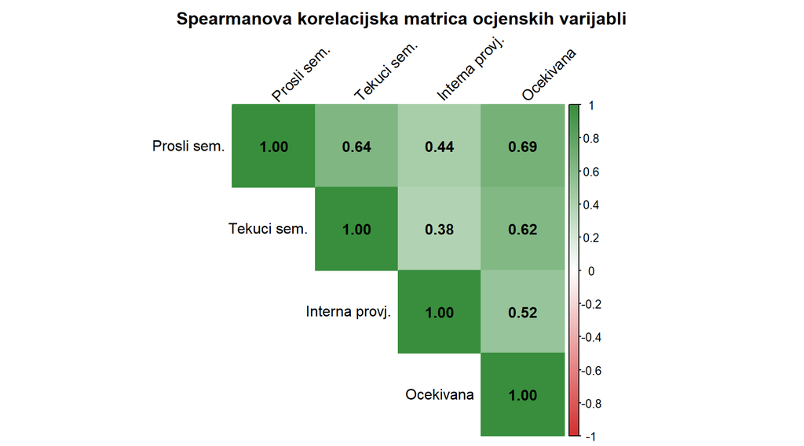

```r
# Spearmanova korelacija između numeričkih ocjenskih varijabli
num_vars <- sap %>%
  select(ocjena_prosli_num, ocjena_tekuci_num,
         interna_provjera_num, ocjena_ocekivana_num)

cor_mat <- cor(num_vars, use = "complete.obs", method = "spearman")

rownames(cor_mat) <- colnames(cor_mat) <-
  c("Prosli sem.", "Tekuci sem.", "Interna provj.", "Ocekivana")

corrplot::corrplot(
  cor_mat,
  method  = "color",
  type    = "upper",
  addCoef.col = "black",
  tl.col  = "black",
  tl.srt  = 45,
  col     = colorRampPalette(c("#D32F2F","white","#388E3C"))(200),
  title   = "Spearmanova korelacijska matrica ocjenskih varijabli",
  mar     = c(0,0,2,0)
)
```

**Tumačenje:** Sve četiri ocjenske varijable pokazuju pozitivnu međusobnu korelaciju, ali jačine variraju. Najsnažnija veza je između prethodnog semestra i očekivane završne ocjene (ρ ≈ 0,69), uz blisku vezu prethodnog i tekućeg semestra (ρ ≈ 0,64), što potvrđuje stabilnost akademskog uspjeha kroz vrijeme — student koji je imao dobre rezultate prethodno, vjerojatno će ih imati i u nastavku studija. Korelacije koje uključuju internu provjeru (`iap`) su slabije do umjerene (ρ ≈ 0,38–0,52); interna provjera korelira s konačnom ocjenom na razini ρ ≈ 0,52, što je tek umjerena veza i upućuje da formativno vrednovanje samo djelomično predviđa sumativni ishod (vidi i KPI-5, koji ne dostiže ciljni prag od 0,60).

# 5 Prediktivna analitika

## 5.1 Klaster analiza profila studenata

Klaster analiza provodi se na numeričkim kodiranjima kategorijskih varijabli kako bi se identificirali prirodni profili studenata relevantni za dizajn e-kolegija.

```r
# Priprema numeričke matrice za klasteriranje
# Koristimo Gower-ovu distancu koja je prikladna za mješovite podatke
library(cluster)

sap_klaster <- sap %>%
  select(
    ocjena_prosli_num, ocjena_tekuci_num,
    interna_provjera_num, ocjena_ocekivana_num,
    pohadjanje, prihod_obitelji, uvjeti_stanovanja,
    lokacija, smjestaj
  ) %>%
  mutate(
    pohadjanje_num       = as.numeric(factor(pohadjanje,
                             levels = c("Poor","Average","Good"))),
    prihod_num           = as.numeric(factor(prihod_obitelji,
                             levels = c("Low","Medium","Am","High","Vh"))),
    uvjeti_num           = as.numeric(factor(uvjeti_stanovanja,
                             levels = c("Poor","Average","Good"))),
    lokacija_num         = ifelse(lokacija == "T", 2, 1),
    smjestaj_num         = ifelse(smjestaj == "Paid", 2, 1)
  ) %>%
  select(ends_with("_num"))

# Gower-ova distanca
gower_dist <- daisy(sap_klaster, metric = "gower")
```

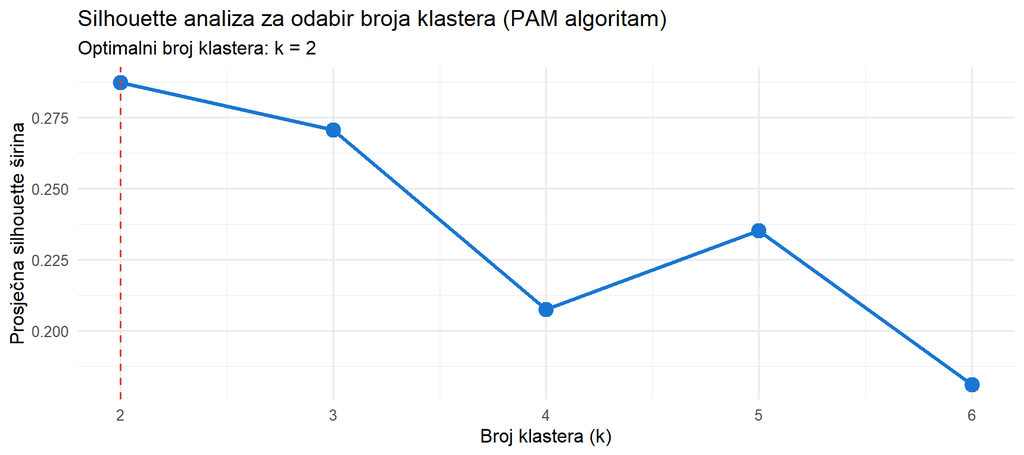

```r
# Određivanje optimalnog broja klastera (silhouette metoda)
sil_width <- map_dbl(2:6, function(k) {
  pam_model <- pam(gower_dist, k = k)
  pam_model$silinfo$avg.width
})

tibble(k = 2:6, silhouette = sil_width) %>%
  ggplot(aes(x = k, y = silhouette)) +
  geom_line(color = "#1976D2", linewidth = 1.2) +
  geom_point(size = 4, color = "#1976D2") +
  geom_vline(xintercept = which.max(sil_width) + 1,
             linetype = "dashed", color = "#E53935") +
  labs(
    title    = "Silhouette analiza za odabir broja klastera (PAM algoritam)",
    subtitle = paste("Optimalni broj klastera: k =", which.max(sil_width) + 1),
    x = "Broj klastera (k)", y = "Prosječna silhouette širina"
  ) +
  theme_minimal(base_size = 12)
```

```r
optimal_k <- which.max(sil_width) + 1
cat("Optimalni broj klastera:", optimal_k, "\n")
```

```
## Optimalni broj klastera: 2
```

```r
# PAM klasteriranje s optimalnim k
pam_result <- pam(gower_dist, k = optimal_k)
sap$klaster <- factor(pam_result$clustering,
                      labels = paste("Klaster", 1:optimal_k))

cat("Raspodjela po klasterima:\n")
```

```
## Raspodjela po klasterima:
```

```r
table(sap$klaster) %>% kable(col.names = c("Klaster", "N")) %>%
  kable_styling(full_width = FALSE)
```

| Klaster | N |
| --- | --- |
| Klaster 1 | 68 |
| Klaster 2 | 63 |

```r
# Profili klastera prema ključnim varijablama
klaster_profil <- sap %>%
  group_by(klaster) %>%
  summarise(
    `Pros. ocjena (prosli)` = round(mean(ocjena_prosli_num), 2),
    `Pros. ocjena (tekuci)` = round(mean(ocjena_tekuci_num), 2),
    `Pros. interna`         = round(mean(interna_provjera_num), 2),
    `Pros. ocekivana`       = round(mean(ocjena_ocekivana_num), 2),
    `Dobro pohadjanje (%)` = round(mean(pohadjanje == "Good") * 100, 1),
    N = n()
  )

klaster_profil %>%
  kable(caption = "Profili klastera prema prosječnim akademskim pokazateljima",
        format.args = list(decimal.mark = ",")) %>%
  kable_styling(bootstrap_options = c("striped","hover"), full_width = FALSE)
```

Profili klastera prema prosječnim akademskim pokazateljima

| klaster | Pros. ocjena (prosli) | Pros. ocjena (tekuci) | Pros. interna | Pros. ocekivana | Dobro pohadjanje (%) | N |
| --- | --- | --- | --- | --- | --- | --- |
| Klaster 1 | 3,72 | 3,66 | 3,87 | 3,81 | 72,1 | 68 |
| Klaster 2 | 2,71 | 2,87 | 3,21 | 2,62 | 11,1 | 63 |

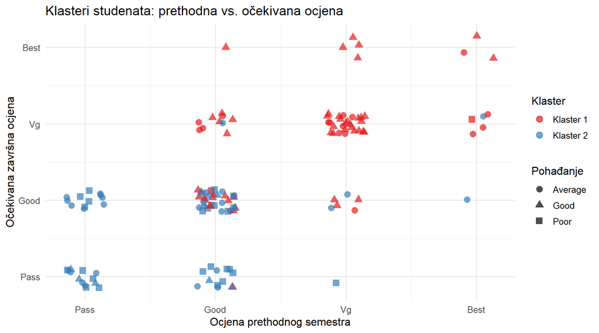

```r
# Vizualizacija klastera: pohađanje × ocjena
ggplot(sap, aes(x = ocjena_prosli_num, y = ocjena_ocekivana_num,
                color = klaster, shape = pohadjanje)) +
  geom_jitter(size = 3, alpha = 0.7, width = 0.15, height = 0.15) +
  scale_color_brewer(palette = "Set1") +
  scale_x_continuous(breaks = 1:5,
    labels = c("Fail","Pass","Good","Vg","Best")) +
  scale_y_continuous(breaks = 1:5,
    labels = c("Fail","Pass","Good","Vg","Best")) +
  labs(
    title  = "Klasteri studenata: prethodna vs. očekivana ocjena",
    x      = "Ocjena prethodnog semestra",
    y      = "Očekivana završna ocjena",
    color  = "Klaster",
    shape  = "Pohađanje"
  ) +
  theme_minimal(base_size = 12)
```

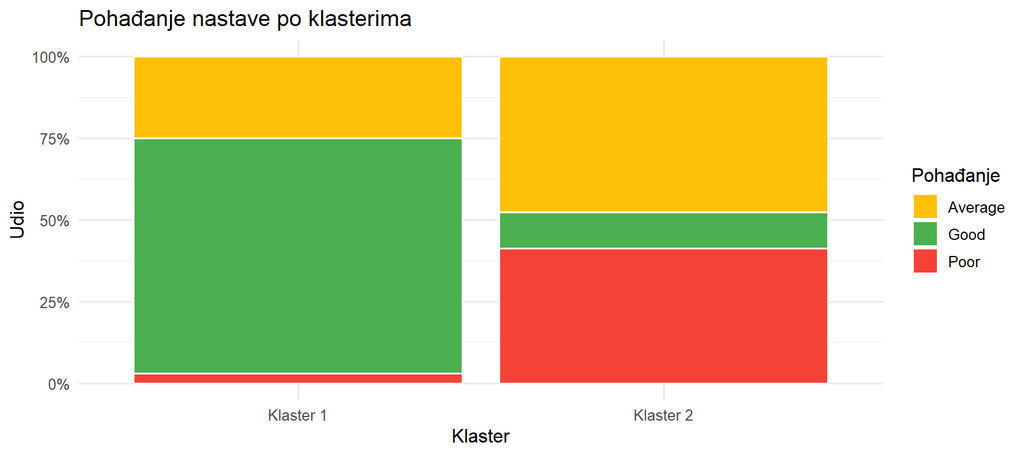

```r
ggplot(sap, aes(x = klaster, fill = pohadjanje)) +
  geom_bar(position = "fill", color = "white") +
  scale_fill_manual(values = c("Good" = "#4CAF50",
                               "Average" = "#FFC107",
                               "Poor" = "#F44336")) +
  scale_y_continuous(labels = percent_format()) +
  labs(title = "Pohađanje nastave po klasterima",
       x = "Klaster", y = "Udio", fill = "Pohađanje") +
  theme_minimal(base_size = 12)
```

**Tumačenje klaster analize i veza s KPI-jevima:**

Silhouette analiza odabrala je **dva klastera** kao optimalnu strukturu (k = 2), pri čemu je prosječna silhouette širina umjerena (≈ 0,29), što ukazuje na postojanje stvarne, ali ne osobito izražene grupne strukture u podacima. Identificirane su dvije jasno razdvojene skupine:

- **Klaster visokog uspjeha i angažmana** (≈ polovica uzorka) — studenti s prosječnom prethodnom i očekivanom ocjenom oko *Vg* (≈ 3,7–3,8 na skali) i visokim udjelom *Good* pohađanja (≈ 72 %). Ova skupina pozitivno doprinosi **KPI-1 (SAP)** i **KPI-3 (SOP)** te su to “autonomni učenici” koji bi profitirali od naprednog sadržaja u e-kolegiju.
- **Klaster rizičnog profila** (≈ polovica uzorka) — studenti s nižim ocjenama (prosjek oko *Good*/*Pass*, ≈ 2,6–2,7) i izrazito niskim *Good* pohađanjem (≈ 11 %). Ova skupina nosi gotovo cijeli teret **KPI-4 (SRS)** i niske **KPI-1 (SAP)** vrijednosti te zahtijeva proaktivne intervencije i pojačano formativno vrednovanje (**KPI-5: KFV**).

Napomena: budući da se broj klastera određuje dinamički (silhouette), pri ponovljenom pokretanju na izmijenjenim podacima broj skupina može se razlikovati; ovdje opisana dvodijelna podjela odgovara trenutnom skupu podataka.

## 5.2 Prediktivni model: Random Forest klasifikacija

Cilj je predvidjeti **pohađanje nastave** (`pohadjanje`) na temelju socioekonomskih i akademskih čimbenika, čime se operacionalizira praćenje **KPI-1 (SAP)** i proaktivna identifikacija studenata koji pogoršavaju **KPI-4 (SRS)**.

```r
set.seed(42)

# Priprema podataka za modeliranje
sap_model <- sap %>%
  select(
    pohadjanje,
    ocjena_prosli, ocjena_tekuci, interna_provjera,
    spol, kasta, lokacija, smjestaj, prihod_obitelji,
    uvjeti_stanovanja, vrsta_skole, ponavljanje,
    velicina_obitelji, putovanje
  ) %>%
  mutate(across(where(is.factor), droplevels)) %>%
  na.omit()

# Podjela na skup za učenje i testiranje (80/20)
idx_train <- createDataPartition(sap_model$pohadjanje, p = 0.8, list = FALSE)
train_set <- sap_model[ idx_train, ]
test_set  <- sap_model[-idx_train, ]

cat("Skup za učenje:", nrow(train_set), "opservacija\n")
```

```
## Skup za učenje: 106 opservacija
```

```r
cat("Skup za testiranje:", nrow(test_set), "opservacija\n")
```

```
## Skup za testiranje: 25 opservacija
```

```r
# Treniranje Random Forest modela
rf_model <- randomForest(
  pohadjanje ~ .,
  data       = train_set,
  ntree      = 300,
  mtry       = 4,
  importance = TRUE
)

print(rf_model)
```

```
##
## Call:
##  randomForest(formula = pohadjanje ~ ., data = train_set, ntree = 300,      mtry = 4, importance = TRUE)
##                Type of random forest: classification
##                      Number of trees: 300
## No. of variables tried at each split: 4
##
##         OOB estimate of  error rate: 55.66%
## Confusion matrix:
##         Average Good Poor class.error
## Average      12   19    7   0.6842105
## Good         11   31    3   0.3111111
## Poor         14    5    4   0.8260870
```

```r
# Predikcija na testnom skupu
pred_rf <- predict(rf_model, newdata = test_set)

# Matrica konfuzije
cm <- confusionMatrix(pred_rf, test_set$pohadjanje)
print(cm)
```

```
## Confusion Matrix and Statistics
##
##           Reference
## Prediction Average Good Poor
##    Average       3    5    3
##    Good          4    6    1
##    Poor          2    0    1
##
## Overall Statistics
##
##                Accuracy : 0.4
##                  95% CI : (0.2113, 0.6133)
##     No Information Rate : 0.44
##     P-Value [Acc > NIR] : 0.7250
##
##                   Kappa : 0.0385
##
##  Mcnemar's Test P-Value : 0.7265
##
## Statistics by Class:
##
##                      Class: Average Class: Good Class: Poor
## Sensitivity                  0.3333      0.5455      0.2000
## Specificity                  0.5000      0.6429      0.9000
## Pos Pred Value               0.2727      0.5455      0.3333
## Neg Pred Value               0.5714      0.6429      0.8182
## Prevalence                   0.3600      0.4400      0.2000
## Detection Rate               0.1200      0.2400      0.0400
## Detection Prevalence         0.4400      0.4400      0.1200
## Balanced Accuracy            0.4167      0.5942      0.5500
```

```r
cat("\n=== TOČNOST MODELA ===\n")
```

```
##
## === TOČNOST MODELA ===
```

```r
cat("Ukupna točnost (Accuracy):", round(cm$overall["Accuracy"] * 100, 1), "%\n")
```

```
## Ukupna točnost (Accuracy): 40 %
```

```r
cat("Stopa većinske klase (No-Information Rate):",
    round(cm$overall["AccuracyNull"] * 100, 1), "%\n")
```

```
## Stopa većinske klase (No-Information Rate): 44 %
```

```r
cat("Kappa koeficijent:", round(cm$overall["Kappa"], 3), "\n")
```

```
## Kappa koeficijent: 0.038
```

```r
cat("Napomena: ako je točnost bliska No-Information Rate, a Kappa blizu 0,",
    "model ne predviđa bolje od pogađanja većinske klase.\n")
```

```
## Napomena: ako je točnost bliska No-Information Rate, a Kappa blizu 0, model ne predviđa bolje od pogađanja većinske klase.
```

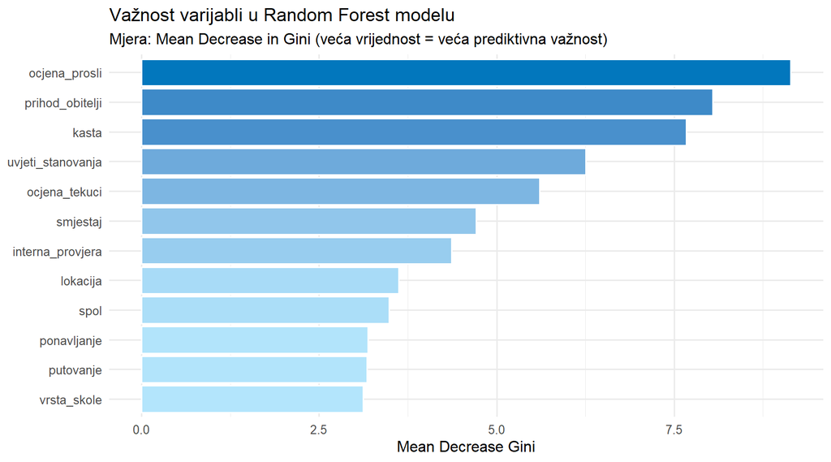

```r
# Važnost varijabli
imp_df <- importance(rf_model) %>%
  as.data.frame() %>%
  rownames_to_column("varijabla") %>%
  arrange(desc(MeanDecreaseGini)) %>%
  head(12)

ggplot(imp_df, aes(x = reorder(varijabla, MeanDecreaseGini),
                   y = MeanDecreaseGini, fill = MeanDecreaseGini)) +
  geom_col(color = "white") +
  coord_flip() +
  scale_fill_gradient(low = "#B3E5FC", high = "#0277BD") +
  labs(
    title    = "Važnost varijabli u Random Forest modelu",
    subtitle = "Mjera: Mean Decrease in Gini (veća vrijednost = veća prediktivna važnost)",
    x = NULL, y = "Mean Decrease Gini", fill = "MDG"
  ) +
  theme_minimal(base_size = 12) +
  theme(legend.position = "none")
```

**Tumačenje Random Forest modela i veza s KPI-jevima:**

**Napomena o vremenskom redoslijedu:** Model uključuje i varijable `ocjena_tekuci` te `interna_provjera` koje opisuju isti ili kasniji vremenski trenutak od pohađanja, pa čak ni retrospektivno nisu prikladne za *proaktivnu* primjenu prije semestra.

Mjera važnosti varijabli (Mean Decrease in Gini) — koju zbog slabe izvedbe modela treba tumačiti isključivo opisno, a ne kao dokaz uzročnosti — najviše rangira **prethodnu akademsku ocjenu** (`ocjena_prosli`), a potom **prihod obitelji** (`prihod_obitelji`), **kastinsku kategoriju** (`kasta`) i **uvjete stanovanja** (`uvjeti_stanovanja`). Varijable poput putovanja (`tt`), vrste škole i veličine obitelji nalaze se pri dnu ljestvice važnosti. Zanimljivo je da ponavljanje godine, iako značajno u regresiji za *ishod*, ovdje ima nisku Gini-važnost za *pohađanje* — što ilustrira da prediktori ishoda i prediktori pohađanja nisu nužno isti. Budući da model ne generalizira, ove rangove ne treba pretvarati u konkretne uzročne tvrdnje niti u temelj za intervencije bez dodatnog, većeg uzorka.

## 5.3 Regresijska analiza: socioekonomski čimbenici i akademski ishod

Dok klaster analiza segmentira studente, a Random Forest predviđa pohađanje, regresijska analiza izravno kvantificira **koliko i koji** socioekonomski čimbenici objašnjavaju varijaciju u akademskom uspjehu (**KPI-3: SOP** i **KPI-2: IAP**). Ovo je ključno za e-kolegij dizajn — intervenirati se može samo tamo gdje postoji znatan i smislen efekt.

```r
# Priprema podataka za regresiju
# Prediktor: socioekonomski profil + pohadjanje (vanjski podaci)
# Ishod: ocjena_ocekivana_num (proxy za KPI-3/SOP i KPI-2/IAP)

sap_reg <- sap %>%
  mutate(
    prihod_ord    = as.numeric(factor(prihod_obitelji,
                      levels = c("Low","Medium","Am","High","Vh"))),
    uvjeti_ord    = as.numeric(factor(uvjeti_stanovanja,
                      levels = c("Poor","Average","Good"))),
    pohadjanje_ord = as.numeric(factor(pohadjanje,
                      levels = c("Poor","Average","Good"))),
    lokacija_bin  = ifelse(lokacija == "T", 1, 0),
    ponavljanje_bin = ifelse(ponavljanje == "Y", 1, 0)
  ) %>%
  select(ocjena_ocekivana_num, ocjena_prosli_num,
         prihod_ord, uvjeti_ord, pohadjanje_ord,
         lokacija_bin, ponavljanje_bin) %>%
  na.omit()

cat("Broj opservacija u regresijskom skupu:", nrow(sap_reg), "\n")
```

```
## Broj opservacija u regresijskom skupu: 131
```

```r
# Višestruka linearna regresija
# (numeričko kodiranje ordinalne ishode — valjana aproksimacija za ≥ 5 razina)
reg_model <- lm(
  ocjena_ocekivana_num ~
    ocjena_prosli_num + prihod_ord + uvjeti_ord +
    pohadjanje_ord + lokacija_bin + ponavljanje_bin,
  data = sap_reg
)

summary(reg_model)
```

```
##
## Call:
## lm(formula = ocjena_ocekivana_num ~ ocjena_prosli_num + prihod_ord +
##     uvjeti_ord + pohadjanje_ord + lokacija_bin + ponavljanje_bin,
##     data = sap_reg)
##
## Residuals:
##      Min       1Q   Median       3Q      Max
## -1.27275 -0.38727 -0.00817  0.38552  1.44363
##
## Coefficients:
##                   Estimate Std. Error t value Pr(>|t|)
## (Intercept)        0.90359    0.28403   3.181 0.001852 **
## ocjena_prosli_num  0.52363    0.06632   7.896 1.31e-12 ***
## prihod_ord         0.01319    0.05115   0.258 0.796996
## uvjeti_ord         0.05137    0.07156   0.718 0.474189
## pohadjanje_ord     0.27952    0.07051   3.964 0.000124 ***
## lokacija_bin       0.11421    0.11334   1.008 0.315566
## ponavljanje_bin   -0.35132    0.10984  -3.199 0.001754 **
## ---
## Signif. codes:  0 '***' 0.001 '**' 0.01 '*' 0.05 '.' 0.1 ' ' 1
##
## Residual standard error: 0.5801 on 124 degrees of freedom
## Multiple R-squared:  0.5545, Adjusted R-squared:  0.533
## F-statistic: 25.72 on 6 and 124 DF,  p-value: < 2.2e-16
```

```r
# Uredni prikaz koeficijenata
broom::tidy(reg_model, conf.int = TRUE) %>%
  mutate(across(where(is.numeric), ~round(., 3))) %>%
  rename(
    Prediktor       = term,
    `Koef. (b)`     = estimate,
    `Std. pogreška` = std.error,
    `t-vrijednost`  = statistic,
    `p-vrijednost`  = p.value,
    `95% CI donji`  = conf.low,
    `95% CI gornji` = conf.high
  ) %>%
  kable(caption = "Koeficijenti višestruke linearne regresije — predikcija akademskog uspjeha",
        format.args = list(decimal.mark = ",")) %>%
  kable_styling(bootstrap_options = c("striped","hover","condensed"), full_width = FALSE)
```

Koeficijenti višestruke linearne regresije — predikcija akademskog uspjeha

| Prediktor | Koef. (b) | Std. pogreška | t-vrijednost | p-vrijednost | 95% CI donji | 95% CI gornji |
| --- | --- | --- | --- | --- | --- | --- |
| (Intercept) | 0,904 | 0,284 | 3,181 | 0,002 | 0,341 | 1,466 |
| ocjena_prosli_num | 0,524 | 0,066 | 7,896 | 0,000 | 0,392 | 0,655 |
| prihod_ord | 0,013 | 0,051 | 0,258 | 0,797 | -0,088 | 0,114 |
| uvjeti_ord | 0,051 | 0,072 | 0,718 | 0,474 | -0,090 | 0,193 |
| pohadjanje_ord | 0,280 | 0,071 | 3,964 | 0,000 | 0,140 | 0,419 |
| lokacija_bin | 0,114 | 0,113 | 1,008 | 0,316 | -0,110 | 0,339 |
| ponavljanje_bin | -0,351 | 0,110 | -3,199 | 0,002 | -0,569 | -0,134 |

```r
# R² i F-test
r2       <- round(summary(reg_model)$r.squared, 3)
r2_adj   <- round(summary(reg_model)$adj.r.squared, 3)
f_stat   <- round(summary(reg_model)$fstatistic[1], 2)
f_pval   <- round(pf(summary(reg_model)$fstatistic[1],
                     summary(reg_model)$fstatistic[2],
                     summary(reg_model)$fstatistic[3],
                     lower.tail = FALSE), 4)

cat("R² =", r2, "| Prilagođeni R² =", r2_adj,
    "| F =", f_stat, "| p =", f_pval, "\n")
```

```
## R² = 0.555 | Prilagođeni R² = 0.533 | F = 25.72 | p = 0
```

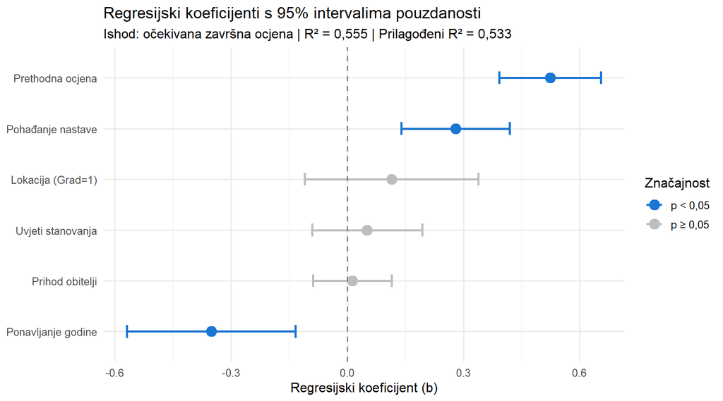

```r
# Vizualizacija koeficijenata (forest plot)
broom::tidy(reg_model, conf.int = TRUE) %>%
  filter(term != "(Intercept)") %>%
  mutate(
    term = recode(term,
      "ocjena_prosli_num" = "Prethodna ocjena",
      "prihod_ord"        = "Prihod obitelji",
      "uvjeti_ord"        = "Uvjeti stanovanja",
      "pohadjanje_ord"    = "Pohađanje nastave",
      "lokacija_bin"      = "Lokacija (Grad=1)",
      "ponavljanje_bin"   = "Ponavljanje godine"
    ),
    znacajnost = ifelse(p.value < 0.05, "p < 0,05", "p ≥ 0,05")
  ) %>%
  ggplot(aes(x = reorder(term, estimate),
             y = estimate, color = znacajnost)) +
  geom_point(size = 4) +
  geom_errorbar(aes(ymin = conf.low, ymax = conf.high),
                width = 0.25, linewidth = 1) +
  geom_hline(yintercept = 0, linetype = "dashed", color = "grey50") +
  coord_flip() +
  scale_color_manual(values = c("p < 0,05" = "#1976D2",
                                "p ≥ 0,05" = "#BDBDBD")) +
  labs(
    title    = "Regresijski koeficijenti s 95% intervalima pouzdanosti",
    subtitle = paste0("Ishod: očekivana završna ocjena | R² = ", hr(r2),
                      " | Prilagođeni R² = ", hr(r2_adj)),
    x = NULL, y = "Regresijski koeficijent (b)",
    color = "Značajnost"
  ) +
  theme_minimal(base_size = 12)
```

**Tumačenje regresijske analize i veza s KPI-jevima:**

Regresijski model objašnjava 55,5 % varijance u **samoprijavljenoj očekivanoj završnoj ocjeni** (R² = 0,555). Varijabla `ocjena_ocekivana` (`esp`) u originalnom skupu podataka predstavlja studentovu *procjenu* vlastite završne ocjene, a ne izmjereni stvarni ishod — što unosi mogućnost optimističke pristranosti. Unatoč tome, model u cjelini statistički je značajan (F-test: p = 0) i objašnjava bitan dio varijance, što je i dalje informativno za razumijevanje studentske percepcije vlastitog napretka — pri čemu, kako pokazuje nastavak, taj efekt nose ponajprije akademske, a ne socioekonomske varijable.

Statistički značajni prediktori (p < 0,05) su sljedeća tri:

- **Prethodna akademska ocjena** (`ocjena_prosli_num`) je najsnažniji prediktor (b ≈ 0,52, p < 0,001) — svako povećanje za jednu razinu (npr. *Pass* → *Good*) predviđa odgovarajući rast u očekivanoj završnoj ocjeni. To znači da e-kolegij nasljeđuje akademski kapital (ili deficit) studenta i treba ga uzeti u obzir pri adaptivnom dizajnu (**KPI-2: IAP**).
- **Pohađanje nastave** (`pohadjanje_ord`) ima pozitivan i značajan koeficijent (b ≈ 0,28, p < 0,001) — studenti s boljim pohađanjem imaju statistički značajno bolji akademski ishod. Ovo potkrepljuje vrijednost **KPI-1 (SAP)** kao pokazatelja povezanog s ishodom (KPI-3: SOP).
- **Ponavljanje godine** (`ponavljanje_bin`) ima značajan negativan koeficijent (b ≈ −0,35, p < 0,01) — studenti koji su ponavljali godinu očekuju niži ishod, što ih izdvaja kao jasnu rizičnu skupinu (**KPI-4: SRS**).

Suprotno čestoj pretpostavci, **prihod obitelji** (`prihod_ord`, p ≈ 0,80) i **uvjeti stanovanja** (`uvjeti_ord`, p ≈ 0,47) **nisu** statistički značajni prediktori u ovom modelu — njihovi koeficijenti su blizu nule. Stoga se na temelju ovih podataka *ne može* tvrditi da niski prihod sam po sebi strukturno snižava akademski ishod; akademska povijest i pohađanje nose gotovo svu objašnjenu varijancu. Ovaj nalaz važan je zbog izbjegavanja neopravdane socioekonomske stigmatizacije pri dizajnu intervencija (vidi etička ograničenja).

# 6 Preporuke za poboljšanje e-kolegija

Na temelju provedenih analiza, identificiramo sljedeće preporuke:

## 6.1 Preporuka 1: Rani sustav upozorenja za rizične studente

**Preporuka:** Implementirati sustav ranog upozorenja temeljen na pravilima (npr. zastavica za studente s prethodnom ocjenom ≤ *Pass*, slabim pohađanjem ili poviješću ponavljanja), nadopunjen LMS podacima (aktualnost pristupa materijalima, predaja zadataka). Označeni studenti trebaju primati proaktivni kontakt tutora ili poruke s ponudama za podršku. Pouzdaniji prediktivni model moguće je razviti tek na većem uzorku.

*Cilj: održati KPI-4 (SRS) ispod 15 % (trenutno 9,9 %) i podići nisku stopu pohađanja KPI-1 (SAP).*

## 6.2 Preporuka 2: Diferenciranje sadržaja e-kolegija prema profilima klastera

**Temelj u podacima:** Klaster analiza empirijski je razdvojila studente u **dvije** skupine — skupinu visokog uspjeha/angažmana i rizičnu skupinu — koje se izrazito razlikuju po akademskom uspjehu i pohađanju (KPI-1: SAP). Niža, “prosječna” putanja navedena je kao pedagoški dizajnerski međukorak, a ne kao zaseban empirijski klaster.

**Preporuka:** Oblikovati e-kolegij s adaptivnim putanjama učenja: - Za *naprednu skupinu* (visoki uspjeh, dobro pohađanje): dodatni izazovni materijali, projekti i peer-učenje — povećava KPI-3 (SOP) prema *Best*. - Kao *međurazinu* (dizajnerski međukorak): pojačano formativno vrednovanje s automatskim feedbackom — povećava KPI-5 (KFV). - Za *rizičnu skupinu*: reducirani kognitivni teret, kratke video-lekcije, učestale provjere razumijevanja — povećava KPI-1 (SAP) i snižava KPI-4 (SRS).

## 6.3 Preporuka 3: Asinkroni pristup i fleksibilizacija pohađanja

**Temelj u podacima:** Ukupna stopa aktivnog pohađanja niska je i **ne dostiže ciljni prag** (KPI-1: SAP = 42,7 % naspram cilja > 60 %) — samo 42,7 % studenata ima pohađanje *Good*. Pohađanje je ujedno značajan prediktor akademskog ishoda u regresiji. Napomena: za razliku od ranije pretpostavke, u ovom uzorku ruralni (Village) studenti *nemaju* lošije pohađanje od gradskih, pa preporuka nije ciljana isključivo na njih nego na cijelu populaciju s ciljem podizanja niske opće stope pohađanja.

**Preporuka:** Uvesti asinkrone inačice svih live-sesija e-kolegija (snimljeni materijali dostupni offline), smanjiti minimalne tehničke zahtjeve platforme (low-bandwidth modus), te razmotriti stipendijska rješenja ili partnerstvo s telekomunikacijskim operaterima za pristup internetu kako bi se uklonile potencijalne tehničke barijere participaciji.

*Cilj: podići KPI-1 (SAP) iznad 60 % i posredno KPI-3 (SOP) fleksibilizacijom pristupa nastavnim sadržajima.*

## 6.4 Preporuka 4: Poboljšanje formativnog vrednovanja

**Temelj u podacima:** KPI-5 (KFV = 0,517) pokazuje da interna provjera znanja umjereno korelira s konačnom ocjenom — postoji prostor za jačanje prediktivne valjanosti formativnog vrednovanja.

**Preporuka:** Povećati učestalost i raznolikost formativnih aktivnosti (kvizovi, diskusijske ploče, peer-review zadatci) koji se mogu iskoristiti za pravovremenu povratnu informaciju studentima i nastavnicima.

*Cilj: podići KPI-5 (KFV) iznad 0,60 jačanjem usklađenosti formativnih i sumativnih instrumenata vrednovanja.*

## 6.5 Preporuka 5: Rodna dimenzija i uključivost

**Temelj u podacima:** U ovom uzorku postoji izražena rodna razlika u pohađanju: studentice imaju *Good* pohađanje u 55,9 % slučajeva naspram 31,9 % studenata, dok je *Poor* pohađanje znatno češće kod studenata (29,2 % vs 11,9 %). Studentice imaju i nešto povoljniju raspodjelu očekivanih ocjena (manje *Pass*, više *Good*), dok su razlike u najvišim kategorijama (*Vg*, *Best*) zanemarive. Ova razlika u pohađanju neravnomjerno utječe na KPI-1 (SAP) po spolu.

**Preporuka:** Analizirati postoje li rodne razlike u pristupu e-nastavnim materijalima i aktivnostima (što se može dodatno istražiti putem LMS podataka) te u slučaju utvrđenih razlika osmisliti mjere podrške koje uklanjaju strukturne prepreke (npr. mentorski program, grupe za podršku).

*Cilj: osigurati da svi KPI-ji dostignu ciljne vrijednosti ravnomjerno za sve demografske podskupine.*

# 7 Zaključak: Prednosti i nedostaci pristupa

## 7.1 Prednosti evaluacije e-kolegija vanjskim podacima

1. **Kontekstualizacija akademskog uspjeha** - Podaci iz LMS-a bilježe *što* student radi unutar platforme, ali ne *zašto*. Vanjski podaci o socioekonomskom statusu, lokaciji i obiteljskim prilikama objašnjavaju uzroke koji stoje iza obrazaca ponašanja.
2. **Proaktivna identifikacija rizika** - Prediktivni modeli izgrađeni na vanjskim podacima mogu upozoriti na rizične studente *prije* nego što problemi postanu vidljivi u LMS aktivnostima (kasno predane zadaće, neredovit pristup materijalima).
3. **Holistička perspektiva** - Kombinacija internih (LMS) i vanjskih podataka omogućuje razumijevanje studenta kao cjelovite osobe, a ne samo kao skupa klikova i pristupa materijalima.
4. **Osnova za diferencirane intervencije** - Klaster analiza temeljem vanjskih profila pruža solidnu osnovu za oblikovanje prilagođenih e-kolegija koji uvažavaju raznolikost studentske populacije.

## 7.2 Nedostaci i ograničenja

1. **Privatnost i etika** - Prikupljanje podataka o prihodima obitelji, kastinskoj kategoriji ili obrazovanju roditelja zahtijeva rigorozne mjere zaštite privatnosti i informirani pristanak. Postoji rizik od diskriminatorne primjene prediktivnih modela (*algorithmic bias*).
2. **Geografska i kulturalna specifičnost** - Skup podataka prikupljen je u specifičnom kulturnom kontekstu (Assam, Indija), pa zaključci o kastinskim kategorijama, prihodima ili jeziku nastave nisu direktno prenosivi na europski ili hrvatski visokoškolski kontekst.
3. **Veličina uzorka i neuravnoteženost** - Sa 131 studentskim zapisom, statistička snaga modela je ograničena. Neke su kategorije izrazito slabo zastupljene (npr. najviši prihod *Vh* sa 6 zapisa ili ocjena *Best* s 8), dok kategorija *Fail* uopće ne postoji — što otežava uravnoteženu klasifikaciju i upravo se odražava u slaboj izvedbi Random Forest modela.
4. **Kauzalnost vs. korelacija** - Identificirane statističke veze (npr. prihod ↔︎ ocjena) ne impliciraju uzročnost. Bez eksperimentalnog dizajna nije moguće tvrditi da intervencija usmjerena na jedan čimbenik nužno poboljšava ishode.
5. **Zastarijevanje podataka** - Socioekonomski status studenata mijenja se tijekom studija. Podaci prikupljeni upitnikom na početku kolegija možda ne odražavaju aktualnu situaciju na kraju semestra.

## 7.3 Završni zaključak

Evaluacija e-kolegija temeljem vanjskih podataka poput socioekonomskog profila, pohađanja nastave i prethodnog akademskog uspjeha pruža vrijedne uvide koji se ne mogu dobiti isključivo analizom LMS logova. Pet definiranih KPI-ja (**SAP, IAP, SOP, SRS, KFV**) dalo je mjerljivu osnovu za procjenu uspješnosti e-kolegija u četiri dimenzije: angažiranost, akademski napredak, prolaznost i valjanost vrednovanja.

Provedene analize — deskriptivna statistika, dijagnostička analiza pohađanja, klasterizacija studentskih profila te regresijski i Random Forest model — dale su sljedeću sliku. Regresija je kao **statistički značajne** prediktore očekivanog ishoda izdvojila **prethodnu ocjenu**, **pohađanje nastave** i **ponavljanje godine** (R² ≈ 0,55), dok socioekonomske varijable (prihod, stambeni uvjeti, lokacija) u ovom uzorku **nisu** bile značajne — nalaz koji poziva na oprez pri socioekonomskom profiliranju. Random Forest model za predikciju pohađanja nije postigao pouzdanost iznad razine većinske klase (Kappa blizu nule), što je očekivano s obzirom na malen uzorak (n = 131) i slabe signale, te ga treba shvatiti kao ilustraciju metode, a ne kao operativni alat. Što se tiče samih KPI-ja: KPI-2 (IAP), KPI-3 (SOP) i KPI-4 (SRS) zadovoljavaju ciljne pragove, dok **KPI-1 (SAP, 42,7 %) i KPI-5 (KFV, 0,52) ne dostižu** zadane ciljeve i predstavljaju prioritetna područja za intervenciju.

Pet predloženih preporuka izravno se oslanjaju na izmjerene vrijednosti KPI-ja: rani sustav upozorenja održava KPI-4 (SRS), adaptivne putanje učenja adresiraju KPI-1 i KPI-3, asinkroni pristup adresira nisku opću stopu pohađanja (KPI-1), a pojačano formativno vrednovanje adresira KPI-5 (KFV) — uz napomenu da su upravo KPI-1 i KPI-5 dvije dimenzije koje trenutno ne zadovoljavaju ciljeve.

Pristup je posebno vrijedan u kontekstu inkluzivnog obrazovanja, ali primjena mora biti praćena snažnim etičkim okvirom koji osigurava da KPI-ji i prediktivni modeli služe kao alati podrške, a ne marginalizacije.

# 8 Literatura i izvori

- **Skup podataka:** Saurabh Pal (2019). *Student Academic Performance Dataset*. UCI Machine Learning Repository. https://archive.ics.uci.edu/dataset/467/student+academics+performance
- Romero, C., & Ventura, S. (2020). Educational data mining and learning analytics: An updated survey. *WIREs Data Mining and Knowledge Discovery*, 10(3), e1355.
- Siemens, G., & Long, P. (2011). Penetrating the Fog: Analytics in Learning and Education. *EDUCAUSE Review*, 46(5), 30–32.
- Dutt, A., Ismail, M. A., & Herawan, T. (2017). A Systematic Review on Educational Data Mining. *IEEE Access*, 5, 15991–16005.
- Credé, M., Roch, S. G., & Kieszczynka, U. M. (2010). Class attendance in college: A meta-analytic review of the relationship of class attendance with grades and student characteristics. *Review of Educational Research*, 80(2), 272–295.
- Arnold, K. E., & Pistilli, M. D. (2012). Course signals at Purdue: Using learning analytics to increase student success. *Proceedings of the 2nd International Conference on Learning Analytics and Knowledge* (LAK ’12), 267–270.
- Campbell, D. T., & Fiske, D. W. (1959). Convergent and discriminant validation by the multitrait-multimethod matrix. *Psychological Bulletin*, 56(2), 81–105.
- Cohen, J. (1988). *Statistical Power Analysis for the Behavioral Sciences* (2nd ed.). Lawrence Erlbaum Associates.
- European Association for Quality Assurance in Higher Education (ENQA). (2015). *Standards and Guidelines for Quality Assurance in the European Higher Education Area (ESG)*. Brussels: EURASHE.

*Dokument generiran korištenjem R Markdown. Svi podaci su stvarni, preuzeti s javno dostupnog UCI ML repozitorija.*